# Tidy Text_Mining

Chapters 3, 4 and 5

Richard Ressler

2020-04-20

# 1 Learning Outcomes

- Manipulate and analyze text data from a variety of sources using tidytext functions
  - Sentiment Analysis
  - Frequency Analysis
  - Relationships Among Words
  - Converting to and from non-tidytext formats

## 1.1 References:

- Most of this material is from [Text Mining with R by Julia Silge and David Robinson](https://www.tidytextmining.com/).
- [Data Science: Theories, Models, Algorithms, and Analytics, Chap 7](https://srdas.github.io/MLBook/TextAnalytics.html)
- Other Examples from [*Nabakov’s Favorite Word is Mauve*](https://www.amazon.com/Nabokovs-Favorite-Word-Mauve-Bestsellers/dp/1501105388)

# 2 Analyzing word and document frequency: tf-idf

## 2.1 Intro

- We have looked at word usage rates and sentiment analysis.
- Now the question is what is the text really about -
  - What is its subject?
  - What are key ideas or topics?
- One way is to compare a text with other texts and look at the relative rates of word usage across them.

## 2.2 Term Frequency - Inverse Document Frequency (tf-idf)

- **Term Frequency** is just how often a term appears in a text (as we did before)
  - Higher is more important - as long as it is meaningful, i.e. not a stop word
- **Inverse Document Frequency** is a function of word usage
  - It penalizes a word’s weight (importance) for commonly used words
  - It increases a word’s weight (importance) if it is not used very often in a collection of other documents.
  - The tf-idf for a term in a single document, given a group of documents, is calculated as follows:

$$\begin{align}
\text{Term Frequency: }\quad tf(\text{term}) =& \frac{n_{\text{term}}}{n_{\text{total words}}} \\
\text{Inverse Document Frequency: }\quad idf(\text{term}) =& \text{ln}\left(\frac{n_{\text{documents}}}{n_{\text{documents containing term}}}\right) \\
tf-idf(\text{term}) =& tf \times idf
\end{align}$$

- Multiplying the $tf$ and $idf$ together to get **tf-idf** is a heuristic measure of the relative importance of a word to a single document out of a collection of documents
- Used in multiple NLP processes

## 2.3 TF in Jane Austen’s Novels

- Load the janeaustenr library

  ```r
  library(janeaustenr)
  ```

- Count the total words and most commonly used words across the books

  ```r
  austen_books() %>%
    unnest_tokens(word, text) %>%
    mutate(word = str_extract(word, "[a-z']+")) %>%
    count(book, word, sort = TRUE) ->
    book_words


  book_words %>%
    group_by(book) %>%
    summarize(total = sum(n)) ->
    total_words

  book_words %>%
    left_join(total_words) ->
    book_words

  book_words
  ```

  ```
  ## # A tibble: 39,708 x 4
  ##    book              word      n  total
  ##    <fct>             <chr> <int>  <int>
  ##  1 Mansfield Park    the    6209 160460
  ##  2 Mansfield Park    to     5477 160460
  ##  3 Mansfield Park    and    5439 160460
  ##  4 Emma              to     5242 160996
  ##  5 Emma              the    5204 160996
  ##  6 Emma              and    4897 160996
  ##  7 Mansfield Park    of     4778 160460
  ##  8 Pride & Prejudice the    4331 122204
  ##  9 Emma              of     4293 160996
  ## 10 Pride & Prejudice to     4163 122204
  ## # … with 39,698 more rows
  ```

- Plot the tf for each book

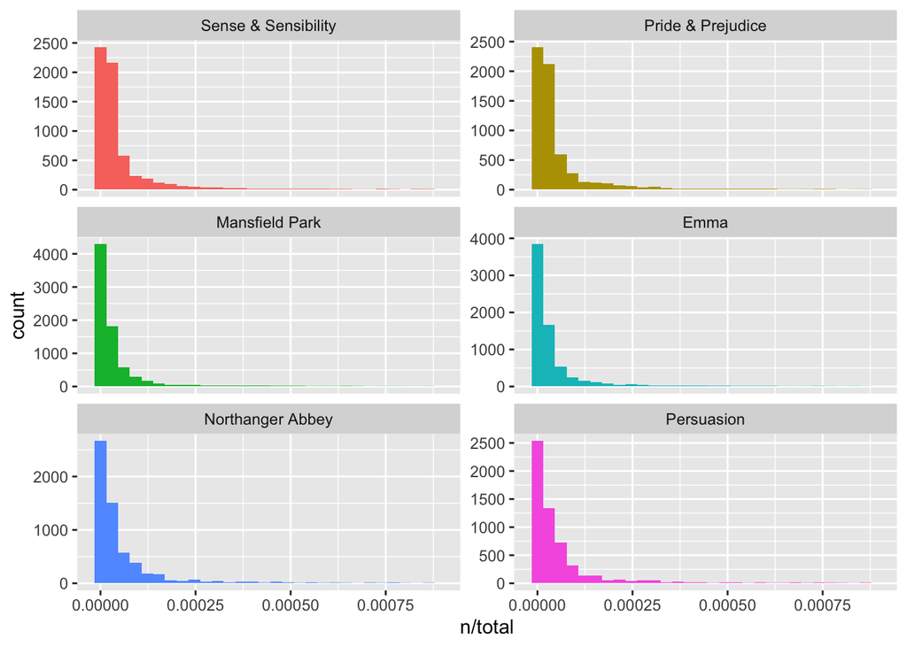

  ```r
  book_words %>%
  ggplot(aes(n/total, fill = book)) +
    geom_histogram(show.legend = FALSE) +
    xlim(NA, 0.0009) +
    facet_wrap(~book, ncol = 2, scales = "free_y")
  ```

- There are numerous words that only occur once in each book

  ```r
  book_words %>%
    filter(n ==1) %>%
    nrow()
  ```

  ```
  ## [1] 15929
  ```

## 2.4 Zipf’s Law

- These long-tailed distributions are common in language.
- The relationship between the frequency a word is used and its rank is well-studied
- A classic version of the relationship is called Zipf’s law, after George Zipf, a 20<sup>th</sup> century American linguist.
- Zipf’s law states" *The frequency of word is inversely proportional to its rank* where rank is its position within the descending frequencies of the words.
- Note, we are NOT removing stop words in these analysis.
- Zipf’s law for Jane Austen

  ```r
  book_words %>%
    group_by(book) %>%
    mutate(rank = row_number(),
           term_frequency = n/total) ->
    freq_by_rank

  freq_by_rank
  ```

  ```
  ## # A tibble: 39,708 x 6
  ## # Groups:   book [6]
  ##    book              word      n  total  rank term_frequency
  ##    <fct>             <chr> <int>  <int> <int>          <dbl>
  ##  1 Mansfield Park    the    6209 160460     1         0.0387
  ##  2 Mansfield Park    to     5477 160460     2         0.0341
  ##  3 Mansfield Park    and    5439 160460     3         0.0339
  ##  4 Emma              to     5242 160996     1         0.0326
  ##  5 Emma              the    5204 160996     2         0.0323
  ##  6 Emma              and    4897 160996     3         0.0304
  ##  7 Mansfield Park    of     4778 160460     4         0.0298
  ##  8 Pride & Prejudice the    4331 122204     1         0.0354
  ##  9 Emma              of     4293 160996     4         0.0267
  ## 10 Pride & Prejudice to     4163 122204     2         0.0341
  ## # … with 39,698 more rows
  ```

- Zipf’s law is often visualized by plotting rank on the x-axis and term frequency on the y-axis, on logarithmic scales.
  - Plotting this way, an inversely proportional relationship will have a constant, negative slope.

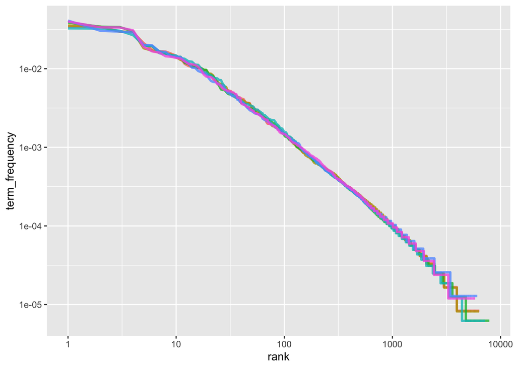

```r
freq_by_rank %>%
  ggplot(aes(rank, term_frequency, color = book)) +
  geom_line(size = 1.1, alpha = 0.8, show.legend = FALSE) +
  scale_x_log10() +
  scale_y_log10()
```

- The pattern is quite similar for all six novels - a negative slope
- It’s not quite linear though.
- Let’s try to model the middle segment between ranks 10 and 500

  ```r
  freq_by_rank %>%
    filter(rank < 500, rank > 10) ->
    rank_subset

  lmout <-  lm(log10(term_frequency) ~ log10(rank), data = rank_subset)
  broom::tidy(lmout)[c(1,2,5)]
  ```

  ```
  ## # A tibble: 2 x 3
  ##   term        estimate p.value
  ##   <chr>          <dbl>   <dbl>
  ## 1 (Intercept)   -0.621       0
  ## 2 log10(rank)   -1.11        0
  ```

- Classic versions of Zipf’s law have $\text{frequency} \propto \frac{1}{\text{rank}}$
- Our model has a slope close to -1.
- Let’s plot this fitted power law

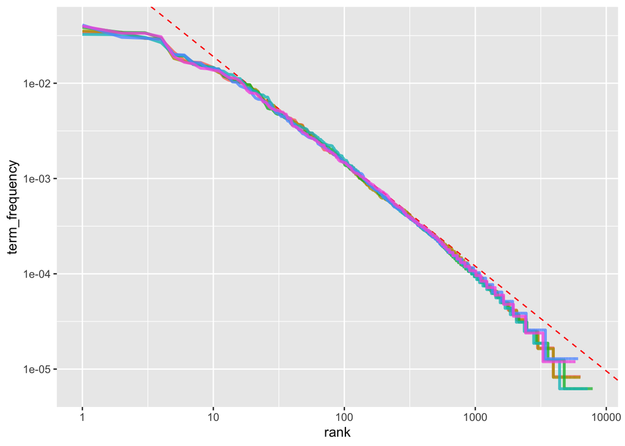

  ```r
  freq_by_rank %>%
    ggplot(aes(rank, term_frequency, color = book)) +
    geom_abline(intercept = -0.62, slope = -1.1, color = "red", linetype = 2) +
    geom_line(size = 1.1, alpha = 0.8, show.legend = FALSE) +
    scale_x_log10() +
    scale_y_log10()
  ```

- We have found a result close to the classic version of Zipf’s law for the corpus of Jane Austen’s novels.
- The deviations at high rank are not uncommon for many kinds of language; a corpus of language often contains fewer rare words than predicted by a single power law.
- The deviations at low rank are more unusual. Jane Austen uses a lower percentage of the most common words than many collections of language.
- This kind of analysis could be extended to compare authors, or to compare any other collections of text; it can be implemented simply using tidy data principles.
- There is a whole field to determining authorship through analysis of an author’s style called Stylometry

## 2.5 The `bind_tf_idf()` function

- The idea of tf-idf is to find the important words a document by decreasing the weight for commonly used words and increasing the weight for words not used very much in a collection of documents, (Jane Austen’s novels)
- Calculating tf-idf attempts to find the words that are important (i.e., common) in a text, but *not too common*.
- Let’s do that now using the tidytext function `bind_tf_idf()`
- The `bind_tf_idf()` function takes a tidy text dataset as input with one row per token (term), per document.
- It returns a data frame with the tf, idf and tf-idf as new columns for each row.

  ```r
  book_words %>% bind_tf_idf(word, book, n) ->
    book_words
  book_words
  ```

  ```
  ## # A tibble: 39,708 x 7
  ##    book              word      n  total     tf   idf tf_idf
  ##    <fct>             <chr> <int>  <int>  <dbl> <dbl>  <dbl>
  ##  1 Mansfield Park    the    6209 160460 0.0387     0      0
  ##  2 Mansfield Park    to     5477 160460 0.0341     0      0
  ##  3 Mansfield Park    and    5439 160460 0.0339     0      0
  ##  4 Emma              to     5242 160996 0.0326     0      0
  ##  5 Emma              the    5204 160996 0.0323     0      0
  ##  6 Emma              and    4897 160996 0.0304     0      0
  ##  7 Mansfield Park    of     4778 160460 0.0298     0      0
  ##  8 Pride & Prejudice the    4331 122204 0.0354     0      0
  ##  9 Emma              of     4293 160996 0.0267     0      0
  ## 10 Pride & Prejudice to     4163 122204 0.0341     0      0
  ## # … with 39,698 more rows
  ```

- The idf, and thus tf-idf, are zero for these extremely common words.
- They appear in all six novels, so the idf term is $log(1) =0$.
- In general the idf (and thus tf-idf) is very low (near zero) for words that occur in many of the documents in a collection; this is how this approach decreases the weight for common words.
- The idf will be higher for words that occur in fewer of the documents in the collection.
- Let’s look at terms with high tf-idf in Jane Austen’s works.

  ```r
  book_words %>%
    select(-total) %>%
    arrange(desc(tf_idf))
  ```

  ```
  ## # A tibble: 39,708 x 6
  ##    book                word          n      tf   idf  tf_idf
  ##    <fct>               <chr>     <int>   <dbl> <dbl>   <dbl>
  ##  1 Sense & Sensibility elinor      623 0.00519  1.79 0.00931
  ##  2 Sense & Sensibility marianne    492 0.00410  1.79 0.00735
  ##  3 Mansfield Park      crawford    493 0.00307  1.79 0.00551
  ##  4 Pride & Prejudice   darcy       374 0.00306  1.79 0.00548
  ##  5 Persuasion          elliot      254 0.00304  1.79 0.00544
  ##  6 Emma                emma        786 0.00488  1.10 0.00536
  ##  7 Northanger Abbey    tilney      196 0.00252  1.79 0.00452
  ##  8 Emma                weston      389 0.00242  1.79 0.00433
  ##  9 Pride & Prejudice   bennet      294 0.00241  1.79 0.00431
  ## 10 Persuasion          wentworth   191 0.00228  1.79 0.00409
  ## # … with 39,698 more rows
  ```

- As we saw before names of people and places tend to be important in each novel.
- None of these occur in all of the novels are are primarily in one or two of them.
- We can plot these

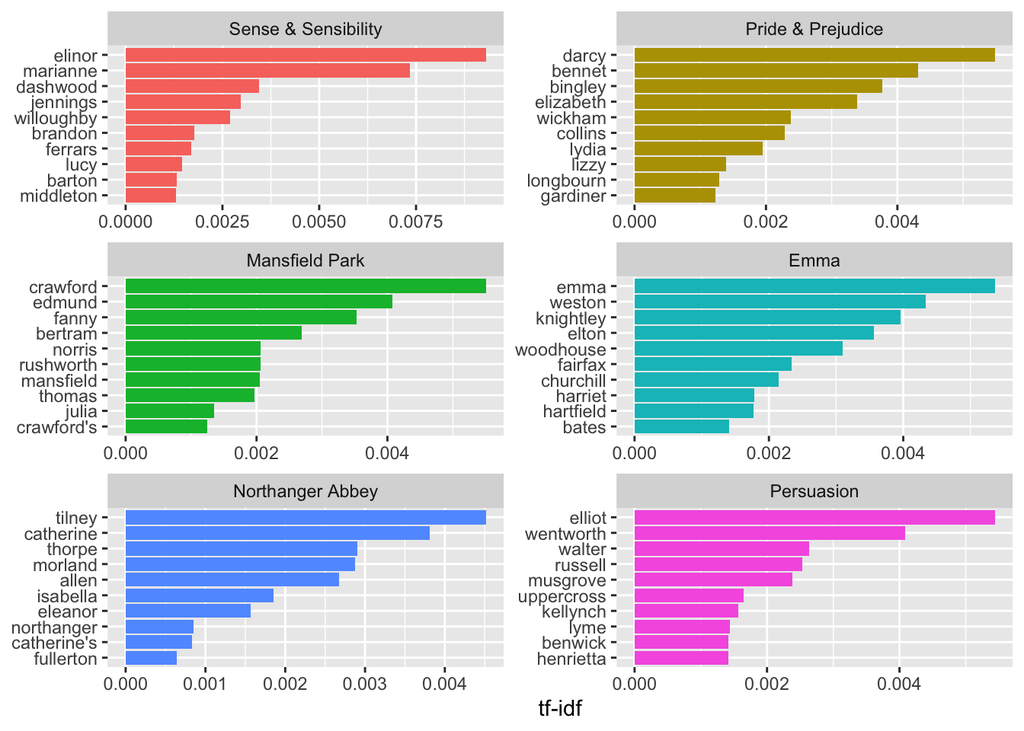

  ```r
  book_words %>%
    arrange(desc(tf_idf)) %>%
    mutate(word = factor(word, levels = rev(unique(word)))) %>%
    group_by(book) %>%
    top_n(10) %>%
    ungroup() %>%
    ggplot(aes(word, tf_idf, fill = book)) +
    geom_col(show.legend = FALSE) +
    labs(x = NULL, y = "tf-idf") +
    facet_wrap(~book, ncol = 2, scales = "free") +
    coord_flip()
  ```

- Measuring tf-idf shows Jane Austen used similar language across her six novels, and what distinguishes one novel from the rest are the proper nouns.
- This is the point of tf-idf; it identifies words important to one document within a collection of documents.

## 2.6 Another example: A corpus of physics texts

Let’s download *Discourse on Floating Bodies* by Galileo Galilei, *Treatise on Light* by Christiaan Huygens, *Experiments with Alternate Currents of High Potential and High Frequency* by Nikola Tesla, and *Relativity: The Special and General Theory* by Albert Einstein.

```r
library(gutenbergr)
physics <- gutenberg_download(c(37729, 14725, 13476, 30155), meta_fields = "author")
physics %>%
  unnest_tokens(word, text) %>%
  mutate(word = str_extract(word, "[a-z']+")) %>%
  count(author, word, sort = TRUE) ->
  physics_words

physics_words
```

```
## # A tibble: 11,849 x 3
##    author              word      n
##    <chr>               <chr> <int>
##  1 Galilei, Galileo    the    3770
##  2 Tesla, Nikola       the    3606
##  3 Huygens, Christiaan the    3553
##  4 Einstein, Albert    the    2995
##  5 Galilei, Galileo    of     2051
##  6 Einstein, Albert    of     2028
##  7 Tesla, Nikola       of     1737
##  8 Huygens, Christiaan of     1708
##  9 Huygens, Christiaan to     1207
## 10 Tesla, Nikola       a      1176
## # … with 11,839 more rows
```

- We are now set to use `bind_tf-idf()` (which helps normalize across the documents of different lengths)

  ```r
  physics_words %>%
    bind_tf_idf(word, author, n) %>%
    mutate(word = fct_reorder(word, tf_idf)) %>%
    mutate(author = factor(author, levels = c("Galilei, Galileo",
                                              "Huygens, Christiaan",
                                              "Tesla, Nikola",
                                              "Einstein, Albert"))) ->
    physics_plot
  ```

- Let’s plot the words by tf-idf

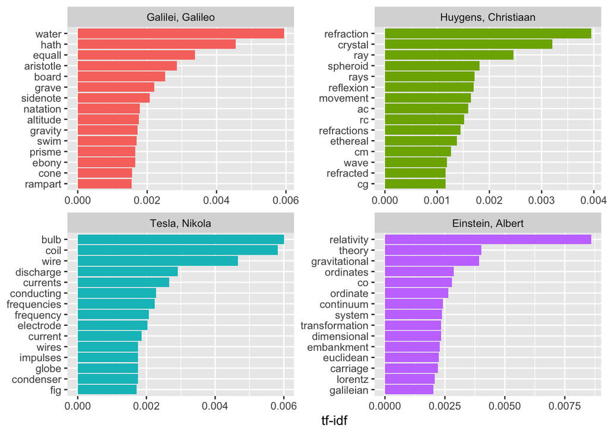

```r
    physics_plot %>%
      group_by(author) %>%
      top_n(15, tf_idf) %>%
      ungroup() %>%
      mutate(word = reorder(word, tf_idf)) %>%
      ggplot(aes(word, tf_idf, fill = author)) +
      geom_col(show.legend = FALSE) +
      labs(x = NULL, y = "tf-idf") +
      facet_wrap(~author, ncol = 2, scales = "free") +
      coord_flip()
```

- Note we have some unusual due to how tidytext separates words by hyphens
  - We could get rid of them early in the process
- We also have what appear to be abbreviations , RC, AC, CM, fig, cg, …

```r
physics %>%
  filter(str_detect(text, "RC")) %>%
  select(text)
```

```
## # A tibble: 44 x 1
##    text
##    <chr>
##  1 line RC, parallel and equal to AB, to be a portion of a wave of light,
##  2 represents the partial wave coming from the point A, after the wave RC
##  3 be the propagation of the wave RC which fell on AB, and would be the
##  4 transparent body; seeing that the wave RC, having come to the aperture
##  5 incident rays. Let there be such a ray RC falling upon the surface
##  6 CK. Make CO perpendicular to RC, and across the angle KCO adjust OK,
##  7 the required refraction of the ray RC. The demonstration of this is,
##  8 explaining ordinary refraction. For the refraction of the ray RC is
##  9 29. Now as we have found CI the refraction of the ray RC, similarly
## 10 the ray _r_C is inclined equally with RC, the line C_d_ will
## # … with 34 more rows
```

- We can remove these by creating our own custom stop words tibble and doing an anti-join.

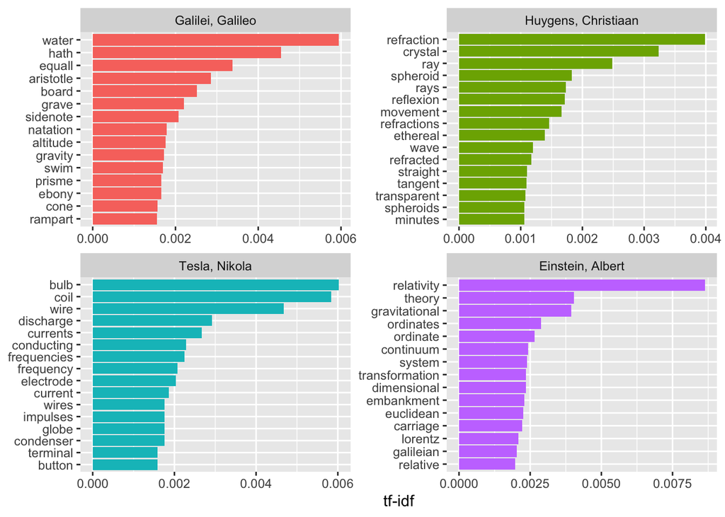

```r
mystopwords <- tibble(word = c("eq", "co", "rc", "ac", "ak", "bn",
                                   "fig", "file", "cg", "cb", "cm",
                               "ab"))

physics_words <- anti_join(physics_words, mystopwords,
                           by = "word")

plot_physics <- physics_words %>%
  bind_tf_idf(word, author, n) %>%
  mutate(word = str_remove_all(word, "_")) %>%
  group_by(author) %>%
  top_n(15, tf_idf) %>%
  ungroup() %>%
  mutate(word = reorder_within(word, tf_idf, author)) %>%
  mutate(author = factor(author, levels = c("Galilei, Galileo",
                                            "Huygens, Christiaan",
                                            "Tesla, Nikola",
                                            "Einstein, Albert")))

ggplot(plot_physics, aes(word, tf_idf, fill = author)) +
  geom_col(show.legend = FALSE) +
  labs(x = NULL, y = "tf-idf") +
  facet_wrap(~author, ncol = 2, scales = "free") +
  coord_flip() +
  scale_x_reordered()
```

- You could do even more cleaning using regex and repeating if desired, - Even at this level, it’s pretty clear the four books have something to do with water, light, electricity and gravity (yes we could also read the titles).

## 2.7 Summary

- tf-idf allows us to find words that are characteristic for one document within a collection of documents, whether that document is a novel or physics text or webpage.

# 3 Relationships between words: n-grams and correlations

- We’ve analyzed words as individual units (within blocks of text of various sizes), and considered their relationships to sentiments or to documents.
- We will now look at text analyses based on the relationships between groups of words, whether examining which words tend to follow others immediately, or that tend to co-occur within the same documents.

## 3.1 Tokenizing by n-gram

- We can use the function `unnest_tokens()` to create consecutive sequences of words, called n-grams.
  - By seeing how often word X is followed by word Y, we can build a model of the relationships between the two words
- We adding the argument `token = "ngrams` to `unnest_tokens()`, with the argument `n=` the number of words we wish to capture in each n-gram.
  - `n = 2` creates pairs of two consecutive words, often called a “bigram”
- Austen Books example

  ```r
  austen_books() %>%
    unnest_tokens(bigram, text, token = "ngrams", n = 2) ->
    austen_bigrams
  austen_bigrams
  ```

  ```
  ## # A tibble: 725,049 x 2
  ##    book                bigram
  ##    <fct>               <chr>
  ##  1 Sense & Sensibility sense and
  ##  2 Sense & Sensibility and sensibility
  ##  3 Sense & Sensibility sensibility by
  ##  4 Sense & Sensibility by jane
  ##  5 Sense & Sensibility jane austen
  ##  6 Sense & Sensibility austen 1811
  ##  7 Sense & Sensibility 1811 chapter
  ##  8 Sense & Sensibility chapter 1
  ##  9 Sense & Sensibility 1 the
  ## 10 Sense & Sensibility the family
  ## # … with 725,039 more rows
  ```

- These bigrams overlap: “sense and” is one token, while “and sensibility” is another.

## 3.2 Counting and filtering n-grams

- Our usual tidy tools apply equally well to n-gram analysis.

  ```r
  austen_bigrams %>%
    count(bigram, sort = TRUE)
  ```

  ```
  ## # A tibble: 211,236 x 2
  ##    bigram       n
  ##    <chr>    <int>
  ##  1 of the    3017
  ##  2 to be     2787
  ##  3 in the    2368
  ##  4 it was    1781
  ##  5 i am      1545
  ##  6 she had   1472
  ##  7 of her    1445
  ##  8 to the    1387
  ##  9 she was   1377
  ## 10 had been  1299
  ## # … with 211,226 more rows
  ```

- As you might expect, a lot of the most common bigrams are pairs of common (uninteresting) words,
- We can get rid of these using `separate()` and remove rows where either is a stop-word.

  ```r
  library(tidyr)

  austen_bigrams %>%
    separate(bigram, c("word1", "word2"), sep = " ")->
    bigrams_separated

  bigrams_separated %>%
    filter(!word1 %in% stop_words$word) %>%
    filter(!word2 %in% stop_words$word) ->
    bigrams_filtered

  # new bigram counts:
  bigrams_filtered %>%
    count(word1, word2, sort = TRUE)->
    bigram_counts

  bigram_counts
  ```

  ```
  ## # A tibble: 33,421 x 3
  ##    word1   word2         n
  ##    <chr>   <chr>     <int>
  ##  1 sir     thomas      287
  ##  2 miss    crawford    215
  ##  3 captain wentworth   170
  ##  4 miss    woodhouse   162
  ##  5 frank   churchill   132
  ##  6 lady    russell     118
  ##  7 lady    bertram     114
  ##  8 sir     walter      113
  ##  9 miss    fairfax     109
  ## 10 colonel brandon     108
  ## # … with 33,411 more rows
  ```

- We can now `unite() them back together

```r
bigrams_filtered %>%
  unite(bigram, word1, word2, sep = " ")->
  bigrams_united

bigrams_united %>%
  count(bigram, sort = TRUE)
```

```
## # A tibble: 33,421 x 2
##    bigram                n
##    <chr>             <int>
##  1 sir thomas          287
##  2 miss crawford       215
##  3 captain wentworth   170
##  4 miss woodhouse      162
##  5 frank churchill     132
##  6 lady russell        118
##  7 lady bertram        114
##  8 sir walter          113
##  9 miss fairfax        109
## 10 colonel brandon     108
## # … with 33,411 more rows
```

### 3.2.1 Analyzing bigrams

- This one-bigram-per-row format is helpful for exploratory analyses of the text.
- A simple example, what are the most common “streets” mentioned in each book:

  ```r
  bigrams_filtered %>%
    filter(word2 == "street") %>%
    count(book, word1, sort = TRUE)
  ```

  ```
  ## # A tibble: 34 x 3
  ##    book                word1           n
  ##    <fct>               <chr>       <int>
  ##  1 Sense & Sensibility berkeley       16
  ##  2 Sense & Sensibility harley         16
  ##  3 Northanger Abbey    pulteney       14
  ##  4 Northanger Abbey    milsom         11
  ##  5 Mansfield Park      wimpole        10
  ##  6 Pride & Prejudice   gracechurch     9
  ##  7 Sense & Sensibility conduit         6
  ##  8 Sense & Sensibility bond            5
  ##  9 Persuasion          milsom          5
  ## 10 Persuasion          rivers          4
  ## # … with 24 more rows
  ```

  ```r
  #or
  bigrams_united %>%
    filter(str_detect(bigram,"street")) %>%
    count(book, bigram, sort = TRUE)
  ```

  ```
  ## # A tibble: 57 x 3
  ##    book                bigram                 n
  ##    <fct>               <chr>              <int>
  ##  1 Sense & Sensibility berkeley street       16
  ##  2 Sense & Sensibility harley street         16
  ##  3 Northanger Abbey    pulteney street       14
  ##  4 Northanger Abbey    milsom street         11
  ##  5 Mansfield Park      wimpole street        10
  ##  6 Pride & Prejudice   gracechurch street     9
  ##  7 Sense & Sensibility conduit street         6
  ##  8 Sense & Sensibility bond street            5
  ##  9 Persuasion          milsom street          5
  ## 10 Persuasion          rivers street          4
  ## # … with 47 more rows
  ```

- A bigram can also be treated as a “term” in a document in the same way that we treated individual words.
- We can calculate the tf-idf of bigrams

  ```r
   bigrams_united %>%
    count(book, bigram) %>%
    bind_tf_idf(bigram, book, n) %>%
    arrange(desc(tf_idf)) ->
    bigram_tf_idf

  bigram_tf_idf
  ```

  ```
  ## # A tibble: 36,217 x 6
  ##    book                bigram                n     tf   idf tf_idf
  ##    <fct>               <chr>             <int>  <dbl> <dbl>  <dbl>
  ##  1 Persuasion          captain wentworth   170 0.0299  1.79 0.0535
  ##  2 Mansfield Park      sir thomas          287 0.0287  1.79 0.0515
  ##  3 Mansfield Park      miss crawford       215 0.0215  1.79 0.0386
  ##  4 Persuasion          lady russell        118 0.0207  1.79 0.0371
  ##  5 Persuasion          sir walter          113 0.0198  1.79 0.0356
  ##  6 Emma                miss woodhouse      162 0.0170  1.79 0.0305
  ##  7 Northanger Abbey    miss tilney          82 0.0159  1.79 0.0286
  ##  8 Sense & Sensibility colonel brandon     108 0.0150  1.79 0.0269
  ##  9 Emma                frank churchill     132 0.0139  1.79 0.0248
  ## 10 Pride & Prejudice   lady catherine      100 0.0138  1.79 0.0247
  ## # … with 36,207 more rows
  ```

- And plot as well

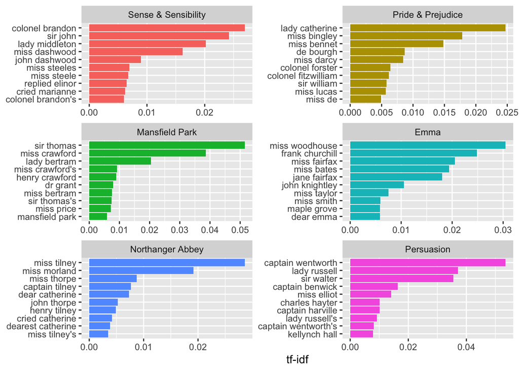

  ```r
  bigram_tf_idf %>%
    group_by(book) %>%
    top_n(10, tf_idf) %>%
    ungroup() %>%
    mutate(bigram = reorder_within(bigram, tf_idf, book)) %>%
    ggplot(aes(bigram, tf_idf, fill = book)) +
      geom_col(show.legend = FALSE) +
      labs(x = NULL, y = "tf-idf") +
      facet_wrap(~book, ncol = 2, scales = "free") +
      coord_flip() +
      scale_x_reordered()
  ```

### 3.2.2 Using bigrams to provide context in sentiment analysis

- Per [Sentimentr](https://github.com/trinker/sentimentr):
- English (and other languages) uses **Valence Shifters**: words that modify the sentiment of other words. Examples include:
  - *A negator*: flips the sign of a polarized word (e.g., “I do not like it.”).
  - *An amplifier or intensifier* increases the impact of a polarized word (e.g., “I really like it.”).
  - *A de-amplifier or diminisher* (downtoner) reduces the impact of a polarized word (e.g., “I hardly like it.”).
  - *An adversative conjunction* overrules the previous clause containing a polarized word (e.g., “I like it but it’s not worth it.”).
- These are fairly common in normal usage:
  - Negators can appear in 20% of sentences with a polarized word
  - Adversative conjunctions can appear 10% of the time
- Also see [Sentiment Classification of Movie Reviews Using Contextual Valence Shifters](https://www.site.uottawa.ca/~diana/publications/ci.pdf)
- When analyzing at the word level or even sentences, the analysis tends to miss the action of valence shifters. At a minimum, a negation cancels out a sentiment word so the sentence (or text block) is neutral as opposed to its true, shifted sentiment.
- A small step towards improving analysis of sentiment is looking at how often words are preceded by the word “not” on the bigrams

  ```r
  bigrams_separated %>%
    filter(word1 == "not") %>%
    count(word1, word2, sort = TRUE)
  ```

  ```
  ## # A tibble: 1,246 x 3
  ##    word1 word2     n
  ##    <chr> <chr> <int>
  ##  1 not   be      610
  ##  2 not   to      355
  ##  3 not   have    327
  ##  4 not   know    252
  ##  5 not   a       189
  ##  6 not   think   176
  ##  7 not   been    160
  ##  8 not   the     147
  ##  9 not   at      129
  ## 10 not   in      118
  ## # … with 1,236 more rows
  ```

- Performing sentiment analysis on the bigram data examines how often sentiment-associated words are preceded by “not” or other negating words.
- We could use this to ignore or even reverse their contribution to the sentiment score.
- Example: Let’s use the AFINN lexicon (has numeric sentiment values, positive or negative).

  ```r
  AFINN <- get_sentiments("afinn")
  AFINN
  ```

  ```
  ## # A tibble: 2,477 x 2
  ##    word       value
  ##    <chr>      <dbl>
  ##  1 abandon       -2
  ##  2 abandoned     -2
  ##  3 abandons      -2
  ##  4 abducted      -2
  ##  5 abduction     -2
  ##  6 abductions    -2
  ##  7 abhor         -3
  ##  8 abhorred      -3
  ##  9 abhorrent     -3
  ## 10 abhors        -3
  ## # … with 2,467 more rows
  ```

- Find the most frequent words preceded by “not” and associated with a sentiment.

  ```r
  bigrams_separated %>%
    filter(word1 == "not") %>%
    inner_join(AFINN, by = c(word2 = "word")) %>%
    count(word2, value, sort = TRUE) ->
    not_words

  not_words
  ```

  ```
  ## # A tibble: 245 x 3
  ##    word2   value     n
  ##    <chr>   <dbl> <int>
  ##  1 like        2    99
  ##  2 help        2    82
  ##  3 want        1    45
  ##  4 wish        1    39
  ##  5 allow       1    36
  ##  6 care        2    23
  ##  7 sorry      -1    21
  ##  8 leave      -1    18
  ##  9 pretend    -1    18
  ## 10 worth       2    17
  ## # … with 235 more rows
  ```

- Which words contributed the most in the “wrong” direction? = Let’s multiply their value by the number of times they appear (so a word with a value of +3 occurring 10 times has as much impact as a word with a value of +1 occurring 30 times).
- Visualize the result with a bar plot (Figure 4.2).

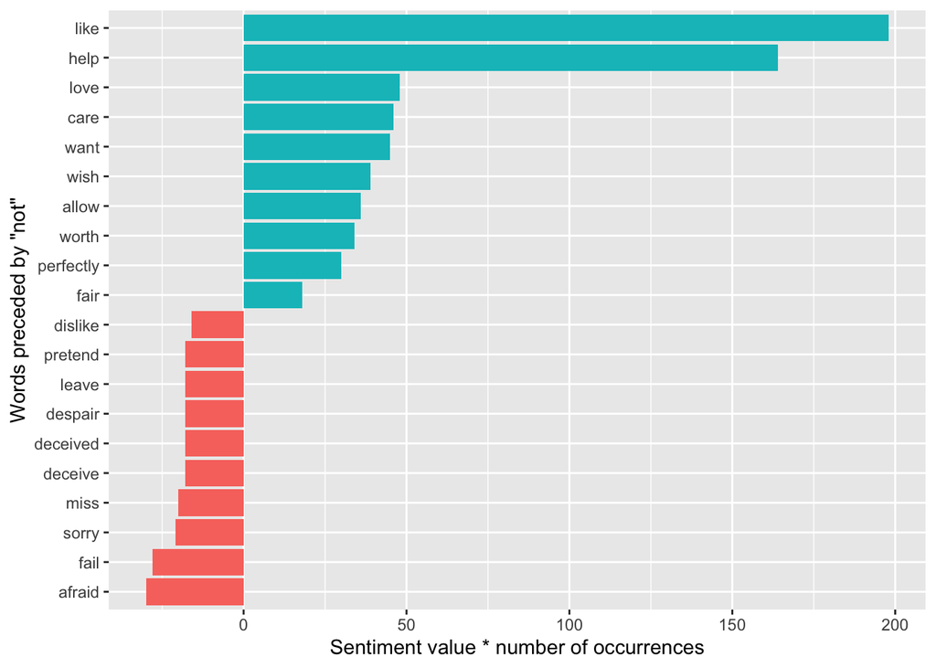

  ```r
  not_words %>%
    mutate(contribution = n * value) %>%
    arrange(desc(abs(contribution))) %>%
    head(20) %>%
    mutate(word2 = reorder(word2, contribution)) %>%
    ggplot(aes(word2, n * value, fill = n * value > 0)) +
    geom_col(show.legend = FALSE) +
    xlab("Words preceded by \"not\"") +
    ylab("Sentiment value * number of occurrences") +
    coord_flip()
  ```

- The bigrams “not like” and “not help” make the text seem much more positive than it is.
- Phrases like “not afraid” and “not fail” sometimes suggest the text is more negative than it is.
- “Not” isn’t the only term that provides some context for the following word.
- Let’s pick four common words that negate the subsequent term and use the same joining and counting approach to examine all of them at once.
- Note: getting the sort right requires some workarounds

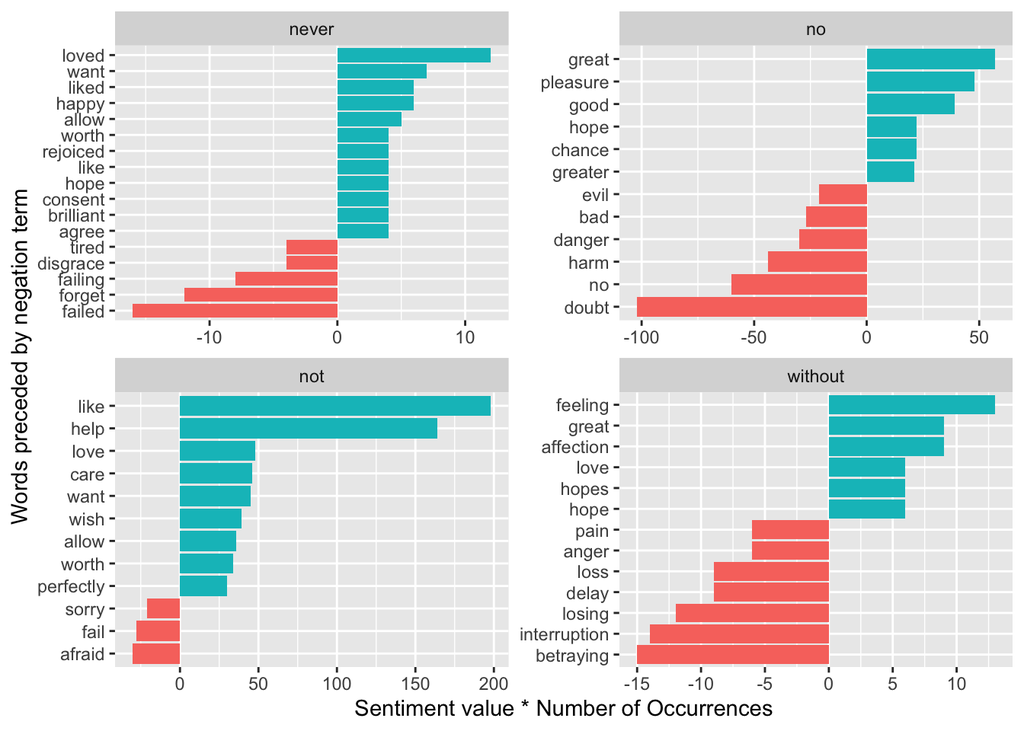

  ```r
  negation_words <- c("not", "no", "never", "without")

  bigrams_separated %>%
    filter(word1 %in% negation_words) %>%
    inner_join(AFINN, by = c(word2 = "word")) %>%
    count(word1, word2, value, sort = TRUE) ->
    negated_words

  negated_words %>%
    mutate(contribution = n * value) %>%
    group_by(word1) %>%
    top_n(12, abs(contribution)) %>%
    ungroup()  %>%
    ggplot(aes(reorder_within(word2,contribution, word1), n * value,
               fill = n * value > 0)) +
      geom_col(show.legend = FALSE) +
      xlab("Words preceded by negation term") +
      ylab("Sentiment value * Number of Occurrences") +
      coord_flip() +
      facet_wrap(~word1, scales = "free") +
      scale_x_discrete(labels = function(x) str_replace(x,"__.+$", ""))
  ```

- If you want to get more in depth with text analysis, suggest looking at the readme for the [Sentimentr Package](https://github.com/trinker/sentimentr)

## 3.3 Visualizing a network of bigrams with ggraph with igraph and ggraph

- If you want to look at more than the top words, you can use a network-node graph to see all of the relationships among words simultaneously.
- We can construct a network-node graph from a tidy object since it has three variables:
  - from: the node an edge is coming from
  - to: the node an edge is going towards
  - weight: A numeric value associated with each edge
- One way to create an igraph object from tidy data is use the `graph_from_data_frame()` function, which takes a data frame of edges with columns for “from”, “to”, and edge attributes (in this case n from our original counts):

  ```r
  library(igraph)
  bigram_counts
  ```

  ```
  ## # A tibble: 33,421 x 3
  ##    word1   word2         n
  ##    <chr>   <chr>     <int>
  ##  1 sir     thomas      287
  ##  2 miss    crawford    215
  ##  3 captain wentworth   170
  ##  4 miss    woodhouse   162
  ##  5 frank   churchill   132
  ##  6 lady    russell     118
  ##  7 lady    bertram     114
  ##  8 sir     walter      113
  ##  9 miss    fairfax     109
  ## 10 colonel brandon     108
  ## # … with 33,411 more rows
  ```

- Let’s filter for only the top combinations and graph

  ```r
  bigram_counts %>%
    filter(n > 20) %>%
    graph_from_data_frame()->
    bigram_graph

  bigram_graph
  ```

  ```
  ## IGRAPH fc64f97 DN-- 91 77 --
  ## + attr: name (v/c), n (e/n)
  ## + edges from fc64f97 (vertex names):
  ##  [1] sir     ->thomas     miss    ->crawford   captain ->wentworth
  ##  [4] miss    ->woodhouse  frank   ->churchill  lady    ->russell
  ##  [7] lady    ->bertram    sir     ->walter     miss    ->fairfax
  ## [10] colonel ->brandon    miss    ->bates      lady    ->catherine
  ## [13] sir     ->john       jane    ->fairfax    miss    ->tilney
  ## [16] lady    ->middleton  miss    ->bingley    thousand->pounds
  ## [19] miss    ->dashwood   miss    ->bennet     john    ->knightley
  ## [22] miss    ->morland    captain ->benwick    dear    ->miss
  ## + ... omitted several edges
  ```

- To plot we need to convert an igraph object into a ggraph with the `ggraph()` function
  - We then add layers to it, (as in ggplot2).
  - For a basic graph we need to add three layers: nodes, edges, and text.

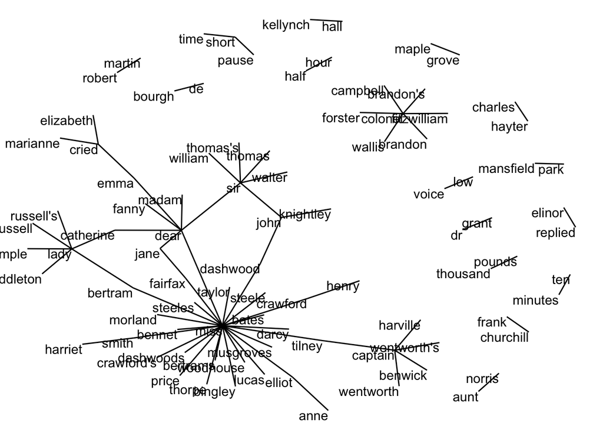

    ```r
    library(ggraph)
    set.seed(17)

    ggraph(bigram_graph, layout = "fr") + #The layout_with_fr() Fruchterman-Reingold layout
      geom_edge_link() +
      #geom_node_point() +
      geom_node_text(aes(label = name), vjust = 1, hjust = 1)+
       theme_void()
    ```

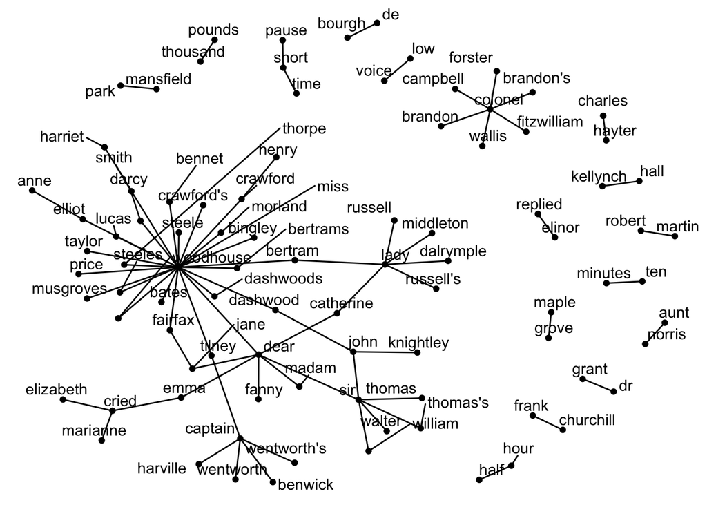

    ```r
    # With repel = TRUE
     ggraph(bigram_graph, layout = "fr") + # layout_with_fr() uses the
       # Fruchterman-Reingold layout
      geom_edge_link() +
      geom_node_point() +
      geom_node_text(aes(label = name), vjust = 1, hjust = 1, repel = TRUE) +
       theme_void()
    ```

- The widyr package helps with other types of analyses you can do with bigrams to include:
  - Counting and correlating among sections
  - Checking pair-wise correlation

# 4 Converting to and from non-tidy formats

- While tidytext format can support a lot of quick analyses, most of the existing R MLP tools aren’t compatible with this format.
- However, tidytext has functions that work with other packages to allow you to convert back and forth between formats as shown in the following graphic (Chapter 5)

[figure not shown]

## 4.1 Tidying a document-term matrix (DTM)

- One of the most common structures is the document-term matrix (or DTM).
  - Each row represents one document (such as a book or article),
  - Each column represents one term, and
  - Each value (typically) contains the number of appearances of the column term in the row document.
- The tidytext package provides two functions to convert between DTM and tidytext formats.
  - `tidy()` turns a DTM into a tidy data frame. This verb comes from the broom package.
  - `cast()` turns a tidy one-term-per-row data frame into a matrix.
    - `cast_sparse()` converts to a sparse matrix (from the Matrix package),
    - `cast_dtm()` converts to a DTM object (from tm),
    - `cast_dfm()` (converts to a dfm object (from quanteda).

## 4.2 Tidying DocumentTermMatrix objects

- Perhaps the most widely used implementation of DTMs in R is the DocumentTermMatrix class in the tm package.
  - Many available text mining datasets are provided in this format.
  - For example, a collection of Associated Press newspaper articles in the “topicmodels” package.

    ```r
    library(tm)

    data("AssociatedPress", package = "topicmodels")
    AssociatedPress
    ```

    ```
    ## <<DocumentTermMatrix (documents: 2246, terms: 10473)>>
    ## Non-/sparse entries: 302031/23220327
    ## Sparsity           : 99%
    ## Maximal term length: 18
    ## Weighting          : term frequency (tf)
    ```

- This is a DTM object that we can use tidytext functions based on the broom package to convert
- Note: documents * terms = 23,522,358 = non-sparse (302031) + number of sparse (23220327)

  ```r
  ap_td <- tidy(AssociatedPress)
  ap_td
  ```

  ```
  ## # A tibble: 302,031 x 3
  ##    document term       count
  ##       <int> <chr>      <dbl>
  ##  1        1 adding         1
  ##  2        1 adult          2
  ##  3        1 ago            1
  ##  4        1 alcohol        1
  ##  5        1 allegedly      1
  ##  6        1 allen          1
  ##  7        1 apparently     2
  ##  8        1 appeared       1
  ##  9        1 arrested       1
  ## 10        1 assault        1
  ## # … with 302,021 more rows
  ```

- Note: only the non-zero values are included in the tidied output
- We can conduct sentiment analysis as before

```r
 ap_td %>%
  inner_join(get_sentiments("bing"), by = c(term = "word"))->
  ap_sentiments

ap_sentiments
```

```
## # A tibble: 30,094 x 4
##    document term    count sentiment
##       <int> <chr>   <dbl> <chr>
##  1        1 assault     1 negative
##  2        1 complex     1 negative
##  3        1 death       1 negative
##  4        1 died        1 negative
##  5        1 good        2 positive
##  6        1 illness     1 negative
##  7        1 killed      2 negative
##  8        1 like        2 positive
##  9        1 liked       1 positive
## 10        1 miracle     1 positive
## # … with 30,084 more rows
```

And plot as usual

[output not shown]

## 4.3 Tidying Document-Feature Matrix (DFM) objects

- The DFM is an alternative implementation of DTM from the quanteda package.
- The quanteda package comes with a corpus of presidential inauguration speeches, which can be converted to a class dfm object using the appropriate function.

  ```r
  data("data_corpus_inaugural", package = "quanteda")
  inaug_dfm <- quanteda::dfm(data_corpus_inaugural, verbose = FALSE)
  inaug_dfm
  ```

  ```
  ## Document-feature matrix of: 58 documents, 9,360 features (91.8% sparse) and 4 docvars.
  ##                  features
  ## docs              fellow-citizens  of the senate and house representatives :
  ##   1789-Washington               1  71 116      1  48     2               2 1
  ##   1793-Washington               0  11  13      0   2     0               0 1
  ##   1797-Adams                    3 140 163      1 130     0               2 0
  ##   1801-Jefferson                2 104 130      0  81     0               0 1
  ##   1805-Jefferson                0 101 143      0  93     0               0 0
  ##   1809-Madison                  1  69 104      0  43     0               0 0
  ##                  features
  ## docs              among vicissitudes
  ##   1789-Washington     1            1
  ##   1793-Washington     0            0
  ##   1797-Adams          4            0
  ##   1801-Jefferson      1            0
  ##   1805-Jefferson      7            0
  ##   1809-Madison        0            0
  ## [ reached max_ndoc ... 52 more documents, reached max_nfeat ... 9,350 more features ]
  ```

- The tidytext implementation of tidy works here as well

  ```r
  inaug_td <- tidy(inaug_dfm)
  inaug_td
  ```

  ```
  ## # A tibble: 44,710 x 3
  ##    document        term            count
  ##    <chr>           <chr>           <dbl>
  ##  1 1789-Washington fellow-citizens     1
  ##  2 1797-Adams      fellow-citizens     3
  ##  3 1801-Jefferson  fellow-citizens     2
  ##  4 1809-Madison    fellow-citizens     1
  ##  5 1813-Madison    fellow-citizens     1
  ##  6 1817-Monroe     fellow-citizens     5
  ##  7 1821-Monroe     fellow-citizens     1
  ##  8 1841-Harrison   fellow-citizens    11
  ##  9 1845-Polk       fellow-citizens     1
  ## 10 1849-Taylor     fellow-citizens     1
  ## # … with 44,700 more rows
  ```

- To find words most specific to each of the inaugural speeches we can use tf-idf for each term-speech pair using the bind_tf_idf() function.

```r
inaug_tf_idf <- inaug_td %>%
  bind_tf_idf(term, document, count) %>%
  arrange(desc(tf_idf))

inaug_tf_idf
```

```
## # A tibble: 44,710 x 6
##    document        term        count      tf   idf tf_idf
##    <chr>           <chr>       <dbl>   <dbl> <dbl>  <dbl>
##  1 1793-Washington arrive          1 0.00680  4.06 0.0276
##  2 1793-Washington upbraidings     1 0.00680  4.06 0.0276
##  3 1793-Washington violated        1 0.00680  3.37 0.0229
##  4 1793-Washington willingly       1 0.00680  3.37 0.0229
##  5 1793-Washington incurring       1 0.00680  3.37 0.0229
##  6 1793-Washington previous        1 0.00680  2.96 0.0201
##  7 1793-Washington knowingly       1 0.00680  2.96 0.0201
##  8 1793-Washington injunctions     1 0.00680  2.96 0.0201
##  9 1793-Washington witnesses       1 0.00680  2.96 0.0201
## 10 1793-Washington besides         1 0.00680  2.67 0.0182
## # … with 44,700 more rows
```

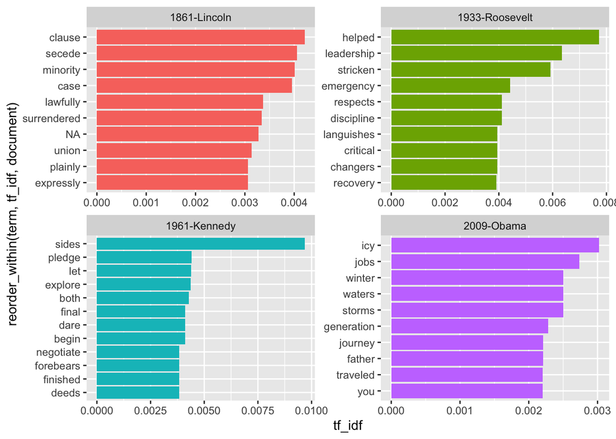

```r
inaug_tf_idf %>%
  filter(document %in% c("1861-Lincoln", "1933-Roosevelt","1961-Kennedy","2009-Obama")) %>%
  mutate(term = str_extract(term, "[a-z']+")) %>%
  group_by(document) %>%
  arrange(desc(tf-idf)) %>%
  top_n(10) %>%
  ungroup() %>%

  ggplot(aes(x=reorder_within(term, tf_idf, document),
             y=tf_idf, fill = document)) +
  geom_col(show.legend = FALSE)+
  facet_wrap(~document, scales = "free") +
  coord_flip() +
  scale_x_discrete(labels = function(x) str_replace(x,"__.+$", ""))
```

## 4.4 Casting tidy text data into a matrix using `cast()`

- We can also go the other way - convert tidytext format to a matrix
- Let’s convert the tidied AP dataset back into a DTM using the `cast_dtm()` function.

  ```r
  ap_td %>%
    cast_dtm(document, term, count)
  ```

  ```
  ## <<DocumentTermMatrix (documents: 2246, terms: 10473)>>
  ## Non-/sparse entries: 302031/23220327
  ## Sparsity           : 99%
  ## Maximal term length: 18
  ## Weighting          : term frequency (tf)
  ```

- Similarly, we could cast the table into a dfm object from quanteda’s dfm with `cast_dfm()`.

  ```r
  ap_td %>%
    cast_dfm(document, term, count)
  ```

  ```
  ## Document-feature matrix of: 2,246 documents, 10,473 features (98.7% sparse).
  ##     features
  ## docs adding adult ago alcohol allegedly allen apparently appeared arrested
  ##    1      1     2   1       1         1     1          2        1        1
  ##    2      0     0   0       0         0     0          0        1        0
  ##    3      0     0   1       0         0     0          0        1        0
  ##    4      0     0   3       0         0     0          0        0        0
  ##    5      0     0   0       0         0     0          0        0        0
  ##    6      0     0   2       0         0     0          0        0        0
  ##     features
  ## docs assault
  ##    1       1
  ##    2       0
  ##    3       0
  ##    4       0
  ##    5       0
  ##    6       0
  ## [ reached max_ndoc ... 2,240 more documents, reached max_nfeat ... 10,463 more features ]
  ```

## 4.5 Tidying corpus objects with metadata

- The corpus data structure can contain documents before tokenization along with metadata.
- For example, the tm package comes with the acq corpus, containing 50 articles from the news service Reuters.

  ```r
  data("acq")
  acq
  ```

  ```
  ## <<VCorpus>>
  ## Metadata:  corpus specific: 0, document level (indexed): 0
  ## Content:  documents: 50
  ```

- A corpus object is structured like a list, with each item containing both text and metadata.
- We can use `tidy()` to construct a table with one row per document, including the metadata (such as id and datetimestamp) as columns alongside the text.

  ```r
  acq_td <- tidy(acq)
  acq_td
  ```

  ```
  ## # A tibble: 50 x 16
  ##    author datetimestamp       description heading id    language origin topics
  ##    <chr>  <dttm>              <chr>       <chr>   <chr> <chr>    <chr>  <chr>
  ##  1 <NA>   1987-02-26 10:18:06 ""          COMPUT… 10    en       Reute… YES
  ##  2 <NA>   1987-02-26 10:19:15 ""          OHIO M… 12    en       Reute… YES
  ##  3 <NA>   1987-02-26 10:49:56 ""          MCLEAN… 44    en       Reute… YES
  ##  4 By Ca… 1987-02-26 10:51:17 ""          CHEMLA… 45    en       Reute… YES
  ##  5 <NA>   1987-02-26 11:08:33 ""          <COFAB… 68    en       Reute… YES
  ##  6 <NA>   1987-02-26 11:32:37 ""          INVEST… 96    en       Reute… YES
  ##  7 By Pa… 1987-02-26 11:43:13 ""          AMERIC… 110   en       Reute… YES
  ##  8 <NA>   1987-02-26 11:59:25 ""          HONG K… 125   en       Reute… YES
  ##  9 <NA>   1987-02-26 12:01:28 ""          LIEBER… 128   en       Reute… YES
  ## 10 <NA>   1987-02-26 12:08:27 ""          GULF A… 134   en       Reute… YES
  ## # … with 40 more rows, and 8 more variables: lewissplit <chr>, cgisplit <chr>,
  ## #   oldid <chr>, places <named list>, people <lgl>, orgs <lgl>,
  ## #   exchanges <lgl>, text <chr>
  ```

- We can then `unnest_tokens()`, for example, to find the most common words across the 50 Reuters articles, .

  ```r
  acq_tokens <- acq_td %>%
    select(-places) %>%
    unnest_tokens(word, text) %>%
    anti_join(stop_words, by = "word")

  # most common words
  acq_tokens %>%
    count(word, sort = TRUE)
  ```

  ```
  ## # A tibble: 1,566 x 2
  ##    word         n
  ##    <chr>    <int>
  ##  1 dlrs       100
  ##  2 pct         70
  ##  3 mln         65
  ##  4 company     63
  ##  5 shares      52
  ##  6 reuter      50
  ##  7 stock       46
  ##  8 offer       34
  ##  9 share       34
  ## 10 american    28
  ## # … with 1,556 more rows
  ```

- or the ones most specific to each article

  ```r
  # tf-idf
  acq_tokens %>%
    count(id, word) %>%
    bind_tf_idf(word, id, n) %>%
    arrange(desc(tf_idf))
  ```

  ```
  ## # A tibble: 2,853 x 6
  ##    id    word         n     tf   idf tf_idf
  ##    <chr> <chr>    <int>  <dbl> <dbl>  <dbl>
  ##  1 186   groupe       2 0.133   3.91  0.522
  ##  2 128   liebert      3 0.130   3.91  0.510
  ##  3 474   esselte      5 0.109   3.91  0.425
  ##  4 371   burdett      6 0.103   3.91  0.405
  ##  5 442   hazleton     4 0.103   3.91  0.401
  ##  6 199   circuit      5 0.102   3.91  0.399
  ##  7 162   suffield     2 0.1     3.91  0.391
  ##  8 498   west         3 0.1     3.91  0.391
  ##  9 441   rmj          8 0.121   3.22  0.390
  ## 10 467   nursery      3 0.0968  3.91  0.379
  ## # … with 2,843 more rows
  ```

## 4.6 Summary

- Text analysis requires working with a variety of tools, many of which use non-tidytext formats.
- You can use tidytext functions to convert between a tidy text data frame and other formats such as DTM, DFM, and Corpus objects containing document metadata.